# PA1_template.Rmd by Maria Koh

This is my first R markdown file

What is mean total number of steps taken per day? For this part of the assignment, you can ignore the missing values in the dataset. Make a histogram of the total number of steps taken each day

```r
  activitydata00 <- read.csv("data/activity.csv", colClasses = "character")
    activitydata00$steps <- as.integer(activitydata00$steps)
    activitydata00$interval <- as.integer(activitydata00$interval)
    activitydata00$date <- as.Date(activitydata00$date,"%Y-%m-%d" )
    activitydata <- subset(activitydata00, activitydata00$steps != "NA")
    activitydata$steps <- as.integer(activitydata$steps)
    activitydata$interval <- as.integer(activitydata$interval)
    activitydata$date <- as.Date(activitydata$date,"%Y-%m-%d" )
```

You can see my plot for the total number of steps taken per day

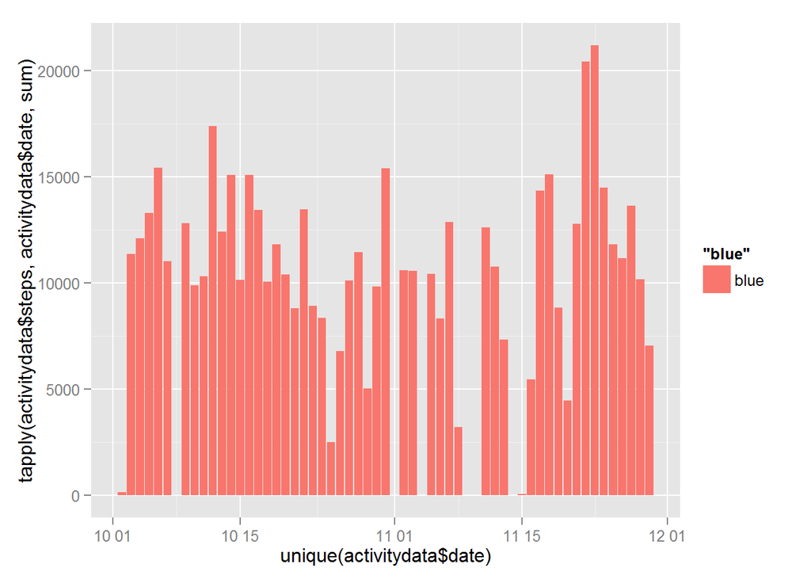

Calculate and report the mean and median total number of steps taken per day

```r
  avtivityReport <- data.frame(ActDate=unique(activitydata$date))
    avtivityReport <- cbind(avtivityReport, StepSum = tapply(activitydata$steps, activitydata$date, sum))
    mean(avtivityReport$StepSum)
```

```
## [1] 10766
```

```r
    median(avtivityReport$StepSum)
```

```
## [1] 10765
```

What is the average daily activity pattern? Make a time series plot (i.e. type = “l”) of the 5-minute interval (x-axis) and the average number of steps taken, averaged across all days (y-axis{)}

```r
  activitydata00  <- cbind(activitydata00 , timeOfDay = sprintf("%04d", activitydata00$interval))
    PatternOfDay<- data.frame(timeOfDay = as.character(unique(activitydata00$timeOfDay)))
  PatternOfDay<- cbind(PatternOfDay, stepMean=  tapply(activitydata00$steps, activitydata00$timeOfDay, mean, na.rm=TRUE))
    PatternOfDay<- cbind(PatternOfDay, stepMedian=  tapply(activitydata00$steps, activitydata00$timeOfDay, median, na.rm=TRUE))
    PatternOfDay<- cbind( PatternOfDay, stepMax= tapply(activitydata00$steps, activitydata00$timeOfDay, max, na.rm=TRUE) )
```

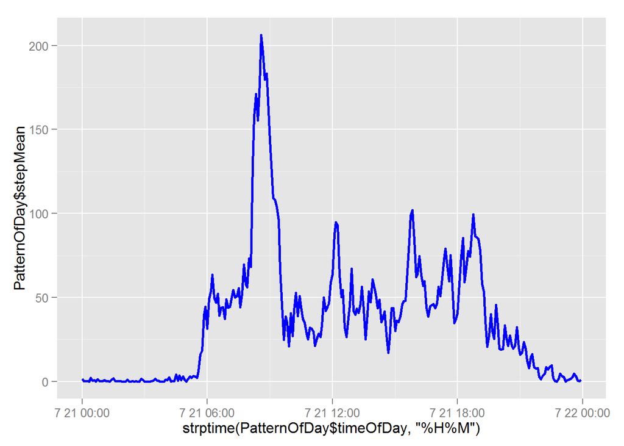

Which 5-minute interval, on average across all the days in the dataset, contains the maximum number of steps?

```r
  PatternOfDay$timeOfDay[which.max (PatternOfDay$stepMax)]
```

[output not shown]

Devise a strategy for filling in all of the missing values in the dataset. The strategy does not need to be sophisticated. For example, you could use the mean/median for that day, or the mean for that 5-minute interval, etc. Create a new dataset that is equal to the original dataset but with the missing data filled in. I decide to fill in the median for that 5-minute interval for missing values

```r
  activitydata01 <- activitydata00
    numdates <-  length(unique(activitydata01$date))
    activitydata01<- cbind( activitydata01, stepMedian = rep(PatternOfDay$stepMedian, numdates))
    naindex <- which( is.na(activitydata01$steps) == TRUE)
    activitydata01[naindex,1] <- activitydata01[naindex,5]
```

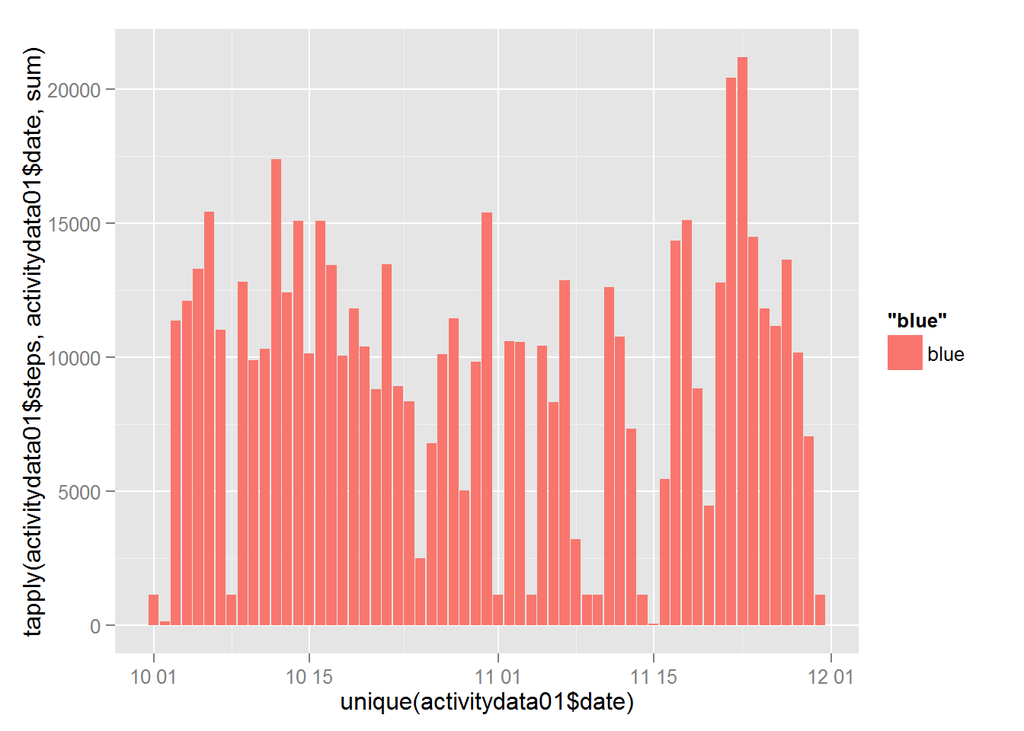

Calculate and report the mean and median total number of steps taken per day.

```r
    avtivityReport01 <- data.frame(ActDate=unique(activitydata01$date))
    avtivityReport01 <- cbind(avtivityReport01, StepSum = tapply(activitydata01$steps, activitydata01$date, sum))
    mean(avtivityReport01$StepSum)
```

```
## [1] 9504
```

```r
    median(avtivityReport01$StepSum)
```

```
## [1] 10395
```

Do these values differ from the estimates from the first part of the assignment? What is the impact of imputing missing data on the estimates of the total daily number of steps?

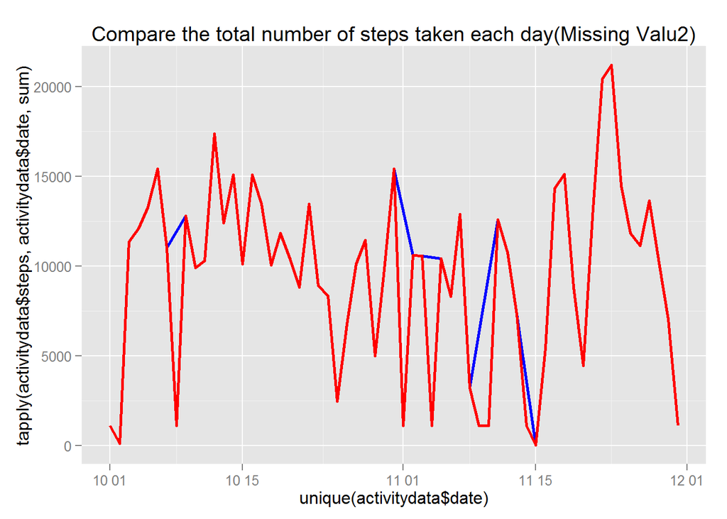

Are there differences in activity patterns between weekdays and weekends? For this part the weekdays() function may be of some help here. Use the dataset with the filled-in missing values for this part. Create a new factor variable in the dataset with two levels ? “weekday” and “weekend” indicating whether a given date is a weekday or weekend day.

```r
  wdaylist <- c("월요일","화요일","수요일","목요일","금요일")
    wdayindex <- which( weekdays(activitydata01$date) %in% wdaylist == TRUE)
    wendindex <- which( weekdays(activitydata01$date) %in% wdaylist == FALSE)
  activitydata01 <- cbind(activitydata01, WdayvsWend=as.character("weekday"))
    activitydata01$WdayvsWend <- as.character(activitydata01$WdayvsWend)
    activitydata01$WdayvsWend[wendindex] <- as.character("weekend")
```

```r
  activitydataWD <- subset(activitydata01, activitydata01$WdayvsWend == "weekday")
  activitydataWE <- subset(activitydata01, activitydata01$WdayvsWend == "weekend")
    PatternOfDayWD<- data.frame(timeOfDay = as.character(unique(activitydataWD$timeOfDay)))
    PatternOfDayWE<- data.frame(timeOfDay = as.character(unique(activitydataWE$timeOfDay)))
    PatternOfDayWD<- cbind(PatternOfDayWD, WDMean=  tapply(activitydataWD$steps, activitydataWD$timeOfDay, mean))
    PatternOfDayWD<- cbind(PatternOfDayWD, WdayWend=as.character("weekday") )
  PatternOfDayWE<- cbind(PatternOfDayWE, WDMean=  tapply(activitydataWE$steps, activitydataWE$timeOfDay, mean))
    PatternOfDayWE<- cbind(PatternOfDayWE, WdayWend=as.character("weekend") )
    PatternOfDayWW <- merge (PatternOfDayWD, PatternOfDayWE, all = TRUE)
```

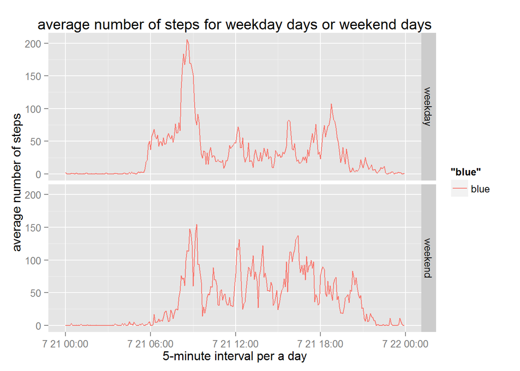